# act_report

## Insights and Visualization Report

### Tumininu Sosanya

A visualization report about the weratedogs wrangle project which was gathered from three datasets and assessed and cleaned into one dataframe.

- tweet_id: tweet identification number
- timestamp: Day the tweet was tweeeted
- source: the tweet link thats shows where the tweet was tweeted from
- Text: the tet written in the tweet
- name : the name of the dogs
- dog_stage : the stage of the dog there are 4 main stage(doggo,puppo,puper,flooper)
- rating_denominator : the rating at the top
- rating_numerator : the rating at the top
- retweet_count : numebers of retweets
- favorite_count: numbers of favorites
- j_url: the link of tweet images
- img_num : the image number betweebn 1- 4
- confidence : the confidence level of the image after running it through a neural network
- predictions : the dog breeds with the highest confidence point after extracting if from the three different predictions

**Which dog stage has the highest favorite counts compared to other dogs stages**

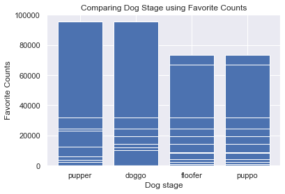

From the bar chart above, both doggo and pupper dog stage have the highest favorite counts of about 98000

**Is there a correlation between favorite count and retweet count?**

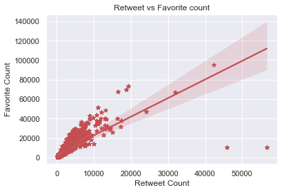

From the chart above, we can see a positive correlation between Favorite count and Retweet count

**What is the top 5 Favorite Dog breed**

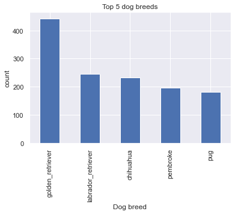